# Spaceship Titanic Temporal Anomaly Forecast

Davide Gamba

Nathan Margni

Christian Pala

# Introduction

The data source for this project comes from the automatic FTL transmission sent by the spaceship titanic, during it’s collision with a temporal anomaly, in an as of yet to be determined galaxy.

The signal was intercepted by the universal receiving locating (URL) ship mercury-redstone 320 at the following frequency: https://www.kaggle.com/competitions/spaceship-titanic/data.

The message was intercepted on the 23rd of Feburary, 2022, galactic standard age.

## Dataset description

Below the description of the contents of the intercepted message:

| Variable | Description |
| --- | --- |
| PassengerId | A unique Id for each passenger. Each Id takes the form gggg_pp where gggg indicates a group the passenger is travelling with and pp is their number within the group. People in a group are often family… |
| HomePlanet | The planet the passenger departed from, typically their planet of permanent residence. |
| CryoSleep | Indicates whether the passenger elected to be put into suspended animation for the duration of the voyage. Passengers in cryosleep are confined to their cabins. |
| Cabin | The cabin number where the passenger is staying. Takes the form deck/num/side, where side can be either P for Port or S for Starboard. |
| Destination | The planet the passenger will be debarking to. |
| Age | The age of the passenger |
| VIP | Whether the passenger has paid for special VIP service during the voyage. |
| RoomService | Amount the passenger has billed for room service. |
| FoodCourt | Amount the passenger has billed for food. |
| ShoppingMall | Amount the passenger has billed at the shopping mall. |
| Spa | Amount the passenger has billed at the spa. |
| VRDeck | Amount the passenger has billed at the vr deck. |
| Name | The first and last names of the passenger |
| Transported | Whether the passenger was transported to another dimension during the space time anomaly |

## Purpose of the analysis

Mandated by the galactic space police central intelligence bureau, the data science junior team comprised by Davide Gamba, Nathan Margni and Christian Pala, was tasked to process the data collected from the spaceship titanic in order to:

1. Determine the time and place of the collision.
2. Recover, as far as possible, the data corrupted by the transmission.
- In case of unrecoverable data, reconstruct what it’s most likely content was.
3. Reconstruct the accident, in particular determine which areas of the ship suffered from a heavier impact with the temporal anomaly.
4. Most importantly, determine the current whereabouts of the passengers present on the ship’s manifesto, but not accounted for in the transmission, a total of 4277 registered galactic citizens.

## Conclusions summary:

1. A first glimpse in the data transmitted showed it was impossible to locate the time and place of the collision, the galactic systems on the ship’s projected route have been placed in high alert and tasked to report in case of positive identification of the spaceship Titanic.
2. We managed to logically reconstruct a good amount of missing values by making reasonable assumptions about the laws governing the ship: We tested many different strategies to impute the missing amenities values, it was especially challenging due to the prevalence of non-spenders skewing the distributions, and we finally selected the knn-imputation’s non-parametric solution. Finally we imputed missing ages with the median value of the known dataset, after checking it’s distribution is positively skewed, and used the mode for categorical variables.

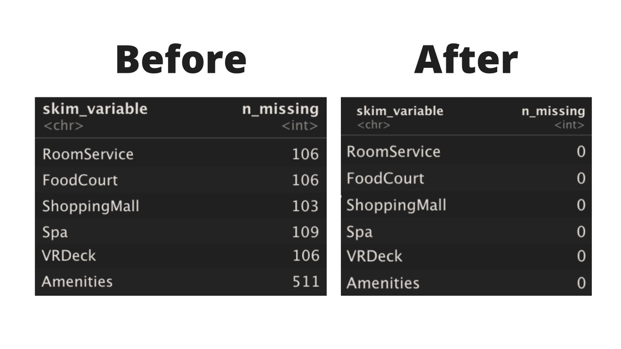

Collision reconstruction:

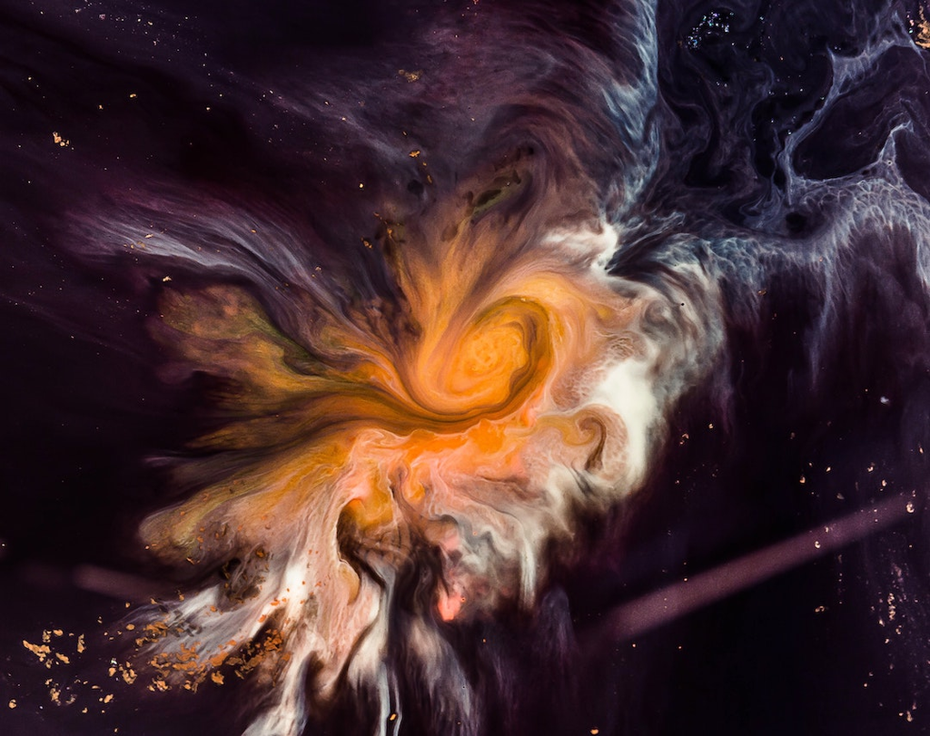

Data source: kaggle.com

3. One important part of the project was to reconstruct the collision, The ship was hit hardest on decks B and C. Passengers in cryosleep, from Europa and / or travelling to 55 Cancri e were more likely transported to an other dimension, the same can be said, to a lesser degree, for passengers boarding on the starship’s side of their cabin, and thus more exposed to space, as we expected. Passengers spending more time on the ship’s amenities, which include many VIP’s, were less likely transported, this surpised us and we assume most of the amenities are in areas of the ship which avoid most of the collision. Schematics of the ship have as of yet not been transmitted, a cross check is highly recommended to very our inferences, information on how we drew the conclusion above is provided in the specific chapter of this report.
4. Since transported is a binary variable we decided to start with a logistic regression as the classifier and our baseline, we then expanded our modelling to a random forest. For both models we tried different pre-processing strategies, and feature selection, but in general the most intuitive model proved to be the better. We highlighted some interesting findings in the way the models prefer to feature select, compared to what we originally envisioned after our data exploration. The final results of the passengers we believe are most likely to be at risk are presented in the final chapter, we found a high likelihood that between 52 and 53 percent of the passengers whose status has not been transmitted by the FTL black-box, have been transported to another dimension by the temporal anomaly. Below we present the confusion matrix of our best random forest classifier:

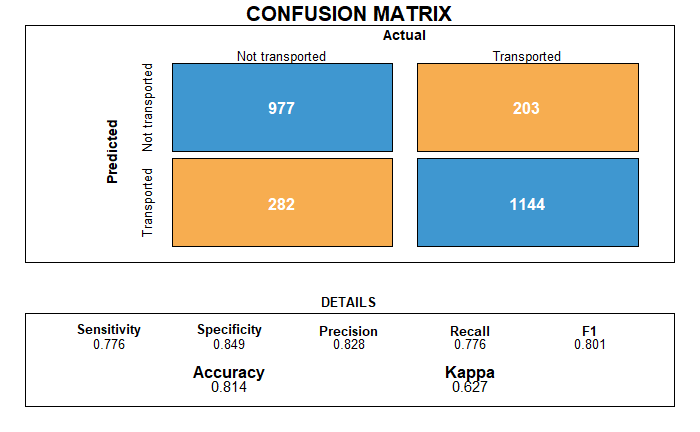

# Data cleaning and exploration:

## Import datasets:

The data from the FTL transmission was automatically transmitted to the data science team.

We left the manual import, in case there are problems with the unofficial fork or the authentication, this requires the files to be locally stored in the data directory of the project, on the local government storage device.

## First look at the data

```r
# strange bug in R that does not properly show the hist plots, solved with this
# workaround found on stackoverflow: https://stackoverflow.com/questions/44253848/skimr-cant-seem-to-produce-the-histograms
Sys.setlocale(locale='Chinese')
```

```
[1] "LC_COLLATE=Chinese (Simplified)_China.936;LC_CTYPE=Chinese (Simplified)_China.936;LC_MONETARY=Chinese (Simplified)_China.936;LC_NUMERIC=C;LC_TIME=Chinese (Simplified)_China.936"
```

```r
skim(train_raw)
```

```
-- Data Summary ------------------------
                           Values
Name                       train_raw
Number of rows             8693
Number of columns          14
_______________________
Column type frequency:
  character                5
  logical                  3
  numeric                  6
________________________
Group variables            None
```

|  | skim_variable | n_missing | complete_rate | min | max | empty | n_unique | whitespace |
| --- | --- | --- | --- | --- | --- | --- | --- | --- |
| 1 | PassengerId | 0 | 1.0000000 | 7 | 7 | 0 | 8693 | 0 |
| 2 | HomePlanet | 201 | 0.9768779 | 4 | 6 | 0 | 3 | 0 |
| 3 | Cabin | 199 | 0.9771080 | 5 | 8 | 0 | 6560 | 0 |
| 4 | Destination | 182 | 0.9790636 | 11 | 13 | 0 | 3 | 0 |
| 5 | Name | 200 | 0.9769930 | 7 | 18 | 0 | 8473 | 0 |

|  | skim_variable | n_missing | complete_rate | mean | count |
| --- | --- | --- | --- | --- | --- |
| 1 | CryoSleep | 217 | 0.9750374 | 0.35830580 | FAL: 5439, TRU: 3037 |
| 2 | VIP | 203 | 0.9766479 | 0.02343934 | FAL: 8291, TRU: 199 |
| 3 | Transported | 0 | 1.0000000 | 0.50362361 | TRU: 4378, FAL: 4315 |

|  | skim_variable | n_missing | complete_rate | mean | sd | p0 | p25 | p50 | p75 | p100 | hist |
| --- | --- | --- | --- | --- | --- | --- | --- | --- | --- | --- | --- |
| 1 | Age | 179 | 0.9794087 | 28.82793 | 14.48902 | 0 | 19 | 27 | 38 | 79 | ▂▇▅▂▁ |
| 2 | RoomService | 181 | 0.9791786 | 224.68762 | 666.71766 | 0 | 0 | 0 | 47 | 14327 | ▇▁▁▁▁ |
| 3 | FoodCourt | 183 | 0.9789486 | 458.07720 | 1611.48924 | 0 | 0 | 0 | 76 | 29813 | ▇▁▁▁▁ |
| 4 | ShoppingMall | 208 | 0.9760727 | 173.72917 | 604.69646 | 0 | 0 | 0 | 27 | 23492 | ▇▁▁▁▁ |
| 5 | Spa | 183 | 0.9789486 | 311.13878 | 1136.70553 | 0 | 0 | 0 | 59 | 22408 | ▇▁▁▁▁ |
| 6 | VRDeck | 188 | 0.9783734 | 304.85479 | 1145.71719 | 0 | 0 | 0 | 46 | 24133 | ▇▁▁▁▁ |

```r
skim(test_raw)
```

```
-- Data Summary ------------------------
                           Values
Name                       test_raw
Number of rows             4277
Number of columns          13
_______________________
Column type frequency:
  character                5
  logical                  2
  numeric                  6
________________________
Group variables            None
```

|  | skim_variable | n_missing | complete_rate | min | max | empty | n_unique | whitespace |
| --- | --- | --- | --- | --- | --- | --- | --- | --- |
| 1 | PassengerId | 0 | 1.0000000 | 7 | 7 | 0 | 4277 | 0 |
| 2 | HomePlanet | 87 | 0.9796586 | 4 | 6 | 0 | 3 | 0 |
| 3 | Cabin | 100 | 0.9766191 | 5 | 8 | 0 | 3265 | 0 |
| 4 | Destination | 92 | 0.9784896 | 11 | 13 | 0 | 3 | 0 |
| 5 | Name | 94 | 0.9780220 | 7 | 18 | 0 | 4176 | 0 |

|  | skim_variable | n_missing | complete_rate | mean | count |
| --- | --- | --- | --- | --- | --- |
| 1 | CryoSleep | 93 | 0.9782558 | 0.36902486 | FAL: 2640, TRU: 1544 |
| 2 | VIP | 93 | 0.9782558 | 0.01768642 | FAL: 4110, TRU: 74 |

|  | skim_variable | n_missing | complete_rate | mean | sd | p0 | p25 | p50 | p75 | p100 | hist |
| --- | --- | --- | --- | --- | --- | --- | --- | --- | --- | --- | --- |
| 1 | Age | 91 | 0.9787234 | 28.65815 | 14.17907 | 0 | 19 | 26 | 37 | 79 | ▂▇▅▂▁ |
| 2 | RoomService | 82 | 0.9808277 | 219.26627 | 607.01129 | 0 | 0 | 0 | 53 | 11567 | ▇▁▁▁▁ |
| 3 | FoodCourt | 106 | 0.9752163 | 439.48430 | 1527.66304 | 0 | 0 | 0 | 78 | 25273 | ▇▁▁▁▁ |
| 4 | ShoppingMall | 98 | 0.9770867 | 177.29553 | 560.82112 | 0 | 0 | 0 | 33 | 8292 | ▇▁▁▁▁ |
| 5 | Spa | 101 | 0.9763853 | 303.05244 | 1117.18601 | 0 | 0 | 0 | 50 | 19844 | ▇▁▁▁▁ |
| 6 | VRDeck | 80 | 0.9812953 | 310.71003 | 1246.99474 | 0 | 0 | 0 | 36 | 22272 | ▇▁▁▁▁ |

### Data storage issues

We noticed the following issues with the transmission format:

- PassengerId is in the form gggg_pp, this is not in galactic tibble format, information on the group could also be useful, so we separated them and stored both.
- Cabin is in the form deck/num/side, this is not in galactic tibble format, information on each category could also be useful, so we separated them and stored both.
- Name is in the form first_name last_name, this is not in galactic tibble format, information on surnames in particular could be useful, so we separated them and stored both.
- For modelling purposes we prefer 0’s and 1’s for binary categorical variables.
- We would like to explore the cumulative use of all amenities on the ship, we created a new feature aggregating them.
- We have a decent amount of missing values, due to FTL transmission corruption, we will dedicate a later chapter to our data reconstruction attempts.

```r
train <- train_raw %>%
    separate(PassengerId, into=c('GroupId','IndividualId'),
             sep="_", remove = FALSE) %>%
    separate(Cabin, into=c('Deck', 'RoomNumber', 'Side'), sep="/") %>%
    separate(Name, into=c('FirstName','LastName'),sep=" ") %>%
    mutate(Transported = ifelse(Transported, 1, 0),
           CryoSleep = ifelse(CryoSleep, 1, 0),
           VIP = ifelse(VIP, 1, 0),
           Side = ifelse(Side == 'S', 1, 0)) %>%
    mutate(Amenities = RoomService + FoodCourt + ShoppingMall + Spa + VRDeck) %>%
    dplyr::select(PassengerId, GroupId,IndividualId,HomePlanet,
           CryoSleep,Deck,RoomNumber,Side,Destination,Age,VIP,RoomService,
           FoodCourt,ShoppingMall,Spa,VRDeck,Amenities,
           FirstName,LastName, Transported)

test <- test_raw %>%
    separate(PassengerId, into=c('GroupId','IndividualId'), sep="_", remove = FALSE) %>%
    separate(Cabin, into=c('Deck', 'RoomNumber', 'Side'), sep="/") %>%
    separate(Name, into=c('FirstName','LastName'),sep=" ") %>%
    mutate(CryoSleep = ifelse(CryoSleep, 1, 0),
           VIP = ifelse(VIP, 1, 0),
           Side = ifelse(Side == 'S', 1, 0)) %>%
    mutate(Amenities = RoomService + FoodCourt + ShoppingMall + Spa + VRDeck) %>%
    dplyr::select(PassengerId, GroupId,IndividualId,HomePlanet,CryoSleep,
                  Deck,RoomNumber,Side,Destination,Age,VIP,RoomService,
                  FoodCourt,ShoppingMall,Spa,VRDeck,Amenities,
           FirstName,LastName)

train$GroupId <-as.integer(train$GroupId)
train$IndividualId <-as.integer(train$IndividualId)
test$GroupId <-as.integer(test$GroupId)
test$IndividualId <-as.integer(test$IndividualId)

skim(train)
```

```
-- Data Summary ------------------------
                           Values
Name                       train
Number of rows             8693
Number of columns          20
_______________________
Column type frequency:
  character                7
  numeric                  13
________________________
Group variables            None
```

|  | skim_variable | n_missing | complete_rate | min | max | empty | n_unique | whitespace |
| --- | --- | --- | --- | --- | --- | --- | --- | --- |
| 1 | PassengerId | 0 | 1.0000000 | 7 | 7 | 0 | 8693 | 0 |
| 2 | HomePlanet | 201 | 0.9768779 | 4 | 6 | 0 | 3 | 0 |
| 3 | Deck | 199 | 0.9771080 | 1 | 1 | 0 | 8 | 0 |
| 4 | RoomNumber | 199 | 0.9771080 | 1 | 4 | 0 | 1817 | 0 |
| 5 | Destination | 182 | 0.9790636 | 11 | 13 | 0 | 3 | 0 |
| 6 | FirstName | 200 | 0.9769930 | 3 | 7 | 0 | 2706 | 0 |
| 7 | LastName | 200 | 0.9769930 | 3 | 11 | 0 | 2217 | 0 |

|  | skim_variable | n_missing | complete_rate | mean | sd | p0 | p25 | p50 | p75 | p100 | hist |
| --- | --- | --- | --- | --- | --- | --- | --- | --- | --- | --- | --- |
| 1 | GroupId | 0 | 1.0000000 | 4.633390e+03 | 2671.0288559 | 1 | 2319 | 4630 | 6883 | 9280 | ▇▇▇▇▇ |
| 2 | IndividualId | 0 | 1.0000000 | 1.517773e+00 | 1.0542413 | 1 | 1 | 1 | 2 | 8 | ▇▁▁▁▁ |
| 3 | CryoSleep | 217 | 0.9750374 | 3.583058e-01 | 0.4795309 | 0 | 0 | 0 | 1 | 1 | ▇▁▁▁▅ |
| 4 | Side | 199 | 0.9771080 | 5.048269e-01 | 0.5000061 | 0 | 0 | 1 | 1 | 1 | ▇▁▁▁▇ |
| 5 | Age | 179 | 0.9794087 | 2.882793e+01 | 14.4890214 | 0 | 19 | 27 | 38 | 79 | ▂▇▅▂▁ |
| 6 | VIP | 203 | 0.9766479 | 2.343934e-02 | 0.1513031 | 0 | 0 | 0 | 0 | 1 | ▇▁▁▁▁ |
| 7 | RoomService | 181 | 0.9791786 | 2.246876e+02 | 666.7176629 | 0 | 0 | 0 | 47 | 14327 | ▇▁▁▁▁ |
| 8 | FoodCourt | 183 | 0.9789486 | 4.580772e+02 | 1611.4892404 | 0 | 0 | 0 | 76 | 29813 | ▇▁▁▁▁ |
| 9 | ShoppingMall | 208 | 0.9760727 | 1.737292e+02 | 604.6964585 | 0 | 0 | 0 | 27 | 23492 | ▇▁▁▁▁ |
| 10 | Spa | 183 | 0.9789486 | 3.111388e+02 | 1136.7055348 | 0 | 0 | 0 | 59 | 22408 | ▇▁▁▁▁ |

[output cut: 3 more lines]

```r
skim(test)
```

```
-- Data Summary ------------------------
                           Values
Name                       test
Number of rows             4277
Number of columns          19
_______________________
Column type frequency:
  character                7
  numeric                  12
________________________
Group variables            None
```

|  | skim_variable | n_missing | complete_rate | min | max | empty | n_unique | whitespace |
| --- | --- | --- | --- | --- | --- | --- | --- | --- |
| 1 | PassengerId | 0 | 1.0000000 | 7 | 7 | 0 | 4277 | 0 |
| 2 | HomePlanet | 87 | 0.9796586 | 4 | 6 | 0 | 3 | 0 |
| 3 | Deck | 100 | 0.9766191 | 1 | 1 | 0 | 8 | 0 |
| 4 | RoomNumber | 100 | 0.9766191 | 1 | 4 | 0 | 1505 | 0 |
| 5 | Destination | 92 | 0.9784896 | 11 | 13 | 0 | 3 | 0 |
| 6 | FirstName | 94 | 0.9780220 | 3 | 7 | 0 | 2130 | 0 |
| 7 | LastName | 94 | 0.9780220 | 3 | 11 | 0 | 1725 | 0 |

|  | skim_variable | n_missing | complete_rate | mean | sd | p0 | p25 | p50 | p75 | p100 | hist |
| --- | --- | --- | --- | --- | --- | --- | --- | --- | --- | --- | --- |
| 1 | GroupId | 0 | 1.0000000 | 4.639296e+03 | 2716.1973685 | 13 | 2249 | 4639.0 | 7030 | 9277 | ▇▇▇▇▇ |
| 2 | IndividualId | 0 | 1.0000000 | 1.498714e+00 | 1.0182207 | 1 | 1 | 1.0 | 2 | 8 | ▇▁▁▁▁ |
| 3 | CryoSleep | 93 | 0.9782558 | 3.690249e-01 | 0.4825984 | 0 | 0 | 0.0 | 1 | 1 | ▇▁▁▁▅ |
| 4 | Side | 100 | 0.9766191 | 5.010773e-01 | 0.5000587 | 0 | 0 | 1.0 | 1 | 1 | ▇▁▁▁▇ |
| 5 | Age | 91 | 0.9787234 | 2.865815e+01 | 14.1790716 | 0 | 19 | 26.0 | 37 | 79 | ▂▇▅▂▁ |
| 6 | VIP | 93 | 0.9782558 | 1.768642e-02 | 0.1318248 | 0 | 0 | 0.0 | 0 | 1 | ▇▁▁▁▁ |
| 7 | RoomService | 82 | 0.9808277 | 2.192663e+02 | 607.0112888 | 0 | 0 | 0.0 | 53 | 11567 | ▇▁▁▁▁ |
| 8 | FoodCourt | 106 | 0.9752163 | 4.394843e+02 | 1527.6630449 | 0 | 0 | 0.0 | 78 | 25273 | ▇▁▁▁▁ |
| 9 | ShoppingMall | 98 | 0.9770867 | 1.772955e+02 | 560.8211232 | 0 | 0 | 0.0 | 33 | 8292 | ▇▁▁▁▁ |
| 10 | Spa | 101 | 0.9763853 | 3.030524e+02 | 1117.1860149 | 0 | 0 | 0.0 | 50 | 19844 | ▇▁▁▁▁ |

[output cut: 2 more lines]

```r
print(train$Side[0:5])
```

```
[1] 0 1 1 1 1
```

## Missing values

This data-set is particularly interesting from the point of view of the missing values. We will show there are ways to reconstruct what the values likely are in some cases, without resorting to statistical imputation,

### Amenities missing values

One way to reconstruct missing values is to check if people who chose to go into cryosleep have missing values for the money spent on amenities, in this case they should clearly be set to 0.

```r
count(filter(train,((CryoSleep == 1) &
             ((is.na(RoomService)) |
             (is.na(FoodCourt)) |
             (is.na(ShoppingMall)) |
             (is.na(Spa)) |
             (is.na(VRDeck))))))
```

| n |
| --- |
| 347 |

As seen from the code above, there are many cases where we can perform such an imputation.

```r
train <-  train %>%
          mutate(RoomService = ifelse(CryoSleep == 1 & !is.na(CryoSleep) , 0 ,
                                      RoomService),
                 FoodCourt = ifelse(CryoSleep == 1 & !is.na(CryoSleep) , 0 ,
                                    FoodCourt),
                 ShoppingMall = ifelse(CryoSleep == 1 & !is.na(CryoSleep) , 0 ,
                                       ShoppingMall),
                 Spa = ifelse(CryoSleep == 1 & !is.na(CryoSleep) , 0 , Spa),
                 VRDeck = ifelse(CryoSleep == 1 & !is.na(CryoSleep), 0, VRDeck))

test <-  test %>%
          mutate(RoomService = ifelse(CryoSleep == 1 & !is.na(CryoSleep) , 0 ,
                                      RoomService),
                 FoodCourt = ifelse(CryoSleep == 1 & !is.na(CryoSleep) , 0 ,
                                    FoodCourt),
                 ShoppingMall = ifelse(CryoSleep == 1 & !is.na(CryoSleep) , 0 ,
                                       ShoppingMall),
                 Spa = ifelse(CryoSleep == 1 & !is.na(CryoSleep) , 0 , Spa),
                 VRDeck = ifelse(CryoSleep == 1 & !is.na(CryoSleep), 0, VRDeck))
```

We noticed some passengers are too young to use amenities, if there are missing values for their amenities, they should be 0 instead. We counted the number of instances.

```r
count(filter(train,((Age < 14) &
             ((is.na(RoomService)) |
             (is.na(FoodCourt)) |
             (is.na(ShoppingMall)) |
             (is.na(Spa)) |
             (is.na(VRDeck)) |
             (is.na(VIP))))))
```

| n |
| --- |
| 76 |

```r
NA
```

And we imputed:

```r
before_na_amenities_train <- train %>%
  dplyr::select(RoomService,FoodCourt,ShoppingMall,Spa,VRDeck) %>%
  summarise_all(list(~sum(is.na(.))))

before_na_amenities_test <- test %>%
  dplyr::select(RoomService,FoodCourt,ShoppingMall,Spa,VRDeck) %>%
  summarise_all(list(~sum(is.na(.))))

train <-  train %>%
          mutate(RoomService = ifelse(Age < 14 & !is.na(Age) , 0 , RoomService),
                 FoodCourt = ifelse(Age < 14 & !is.na(Age) , 0 , FoodCourt),
                 ShoppingMall = ifelse(Age < 14 & !is.na(Age) , 0 , ShoppingMall),
                 Spa = ifelse(Age < 14 & !is.na(Age) , 0 , Spa),
                 VRDeck = ifelse(Age < 14 & !is.na(Age), 0, VRDeck))

test <-  test %>%
          mutate(RoomService = ifelse(Age < 14 & !is.na(Age) , 0 , RoomService),
                 FoodCourt = ifelse(Age < 14 & !is.na(Age) , 0 , FoodCourt),
                 ShoppingMall = ifelse(Age < 14 & !is.na(Age) , 0 , ShoppingMall),
                 Spa = ifelse(Age < 14 & !is.na(Age) , 0 , Spa),
                 VRDeck = ifelse(Age < 14 & !is.na(Age), 0, VRDeck))

after_na_amenities_train <- train %>%
  dplyr::select(RoomService,FoodCourt,ShoppingMall,Spa,VRDeck) %>%
  summarise_all(list(~sum(is.na(.))))

after_na_amenities_test <- test %>%
  dplyr::select(RoomService,FoodCourt,ShoppingMall,Spa,VRDeck) %>%
  summarise_all(list(~sum(is.na(.))))
```

### Missing home planets and destinations.

Another assumption we can make, is that people with the same LastName are travelling from the same planet to the same destination, does this bear out?

```r
train %>%
    group_by(LastName) %>%
    summarize(HomePlanets = n_distinct(HomePlanet),
              Destinations = n_distinct(Destination)) %>%
    arrange(desc(HomePlanets), desc(Destinations)) %>%
    drop_na()
```

| LastName | HomePlanets | Destinations |
| --- | --- | --- |
| Barris | 2 | 4 |
| Belley | 2 | 4 |
| Dal | 2 | 4 |
| Estron | 2 | 4 |
| Harverez | 2 | 4 |
| Mccarveymon | 2 | 4 |
| Rodger | 2 | 4 |
| Toddleton | 2 | 4 |
| Alshipson | 2 | 3 |
| Bakerrison | 2 | 3 |

[output cut: 990 more lines]

We can see it’s a decent assumption for home planet, where it would be a correct assumption in most cases and a 50:50 in the remaining ~ 8% of cases. It does not generally hold for destinations however, so we will not use this method to impute destination missing values.

```r
train_withna <- train %>% filter(is.na(LastName))
train_withoutna <- train %>% filter(!is.na(LastName))

try_train <- train_withoutna %>%
       dplyr::select(LastName,HomePlanet)

d_train <- na.omit(try_train)

try_train <-
  transform(try_train, HomePlanet = d_train$HomePlanet[match(LastName,
                                                             d_train$LastName)])

train_withoutna$HomePlanet <- try_train$HomePlanet

train <- rbind(train_withna,train_withoutna)

test_withna <- test %>% filter(is.na(LastName))
test_withoutna <- test %>% filter(!is.na(LastName))

try_test <- test_withoutna %>%
       dplyr::select(LastName,HomePlanet)

d_test <- na.omit(try_test)

try_test <-
  transform(try_test, HomePlanet = d_test$HomePlanet[match(LastName,
                                                           d_test$LastName)])

test_withoutna$HomePlanet <- try_test$HomePlanet

test <- rbind(test_withna,test_withoutna)
```

### Missing VIPs

Like the other amenities, VIP is very likely not available for young passenger, we found no passenger younger than 18 registered as a VIP in both datasets.

This is another imputation we can therefore quite safely make.

```r
train %>% dplyr::select(VIP,Age) %>% filter(!is.na(Age) & Age < 18 & !is.na(VIP)) %>%
summarize(Ages = n_distinct(Age),VIPs = n_distinct(VIP))
```

| Ages | VIPs |
| --- | --- |
| 18 | 1 |

```r
test %>% dplyr::select(VIP,Age) %>% filter(!is.na(Age) & Age < 18 & !is.na(VIP)) %>%
summarize(Ages = n_distinct(Age),VIPs = n_distinct(VIP),
          VIP_Values = unique(VIP))
```

| Ages | VIPs | VIP_Values |
| --- | --- | --- |
| 18 | 1 | 0 |

```r
train <- train %>%
          mutate(VIP = ifelse(Age < 18 & !is.na(Age), 0 , VIP))
test <- test %>%
          mutate(VIP = ifelse(Age < 18 & !is.na(Age), 0 , VIP))
```

## Other missing values

For the amenities missing values, we decided to create our own model to predict what values should have been in those columns based on the other information available.

For categorical variables we substituted with the mode, for the age we imputed with the median, after noticing we could not produce a linear model to impute, it was the most robust metric we have seen.

```r
# recalculating total Amenities:
train$Amenities = train$RoomService + train$FoodCourt +
  train$ShoppingMall + train$Spa + train$VRDeck

test$Amenities = test$RoomService + test$FoodCourt +
  test$ShoppingMall + test$Spa + test$VRDeck

# Filling NA Age variables with the median, since age is positively skewed we
# chose the most robust measure.
train$Age[is.na(train$Age)] = median(train$Age, na.rm = TRUE)
test$Age[is.na(test$Age)] = median(test$Age, na.rm = TRUE)

# Filling NA categorical or binary variables with the mode
na_replace_Mode <- function(x) {
  ux <- unique(na.omit(x))
  x[is.na(x)] <- ux[which.max(tabulate(match(x, ux)))]
  x
}

train <- transform(train, HomePlanet = ave(HomePlanet, FUN = na_replace_Mode))
test <- transform(test, HomePlanet = ave(HomePlanet, FUN = na_replace_Mode))

train <- transform(train, Destination = ave(Destination, FUN = na_replace_Mode))
test <- transform(test, Destination = ave(Destination, FUN = na_replace_Mode))

train <- transform(train, VIP  = ave(VIP , FUN = na_replace_Mode))
test <- transform(test, VIP  = ave(VIP , FUN = na_replace_Mode))

train <- transform(train, CryoSleep  = ave(CryoSleep , FUN = na_replace_Mode))
test <- transform(test, CryoSleep  = ave(CryoSleep , FUN = na_replace_Mode))

train <- transform(train, Deck  = ave(Deck , FUN = na_replace_Mode))
test <- transform(test, Deck  = ave(Deck , FUN = na_replace_Mode))

train <- transform(train, Side  = ave(Side , FUN = na_replace_Mode))
test <- transform(test, Side  = ave(Side , FUN = na_replace_Mode))

#checking remaining missing values
sapply(train, function(x) sum(is.na(x)))
```

```
 PassengerId      GroupId IndividualId   HomePlanet    CryoSleep         Deck   RoomNumber         Side
           0            0            0            0            0            0          199            0
 Destination          Age          VIP  RoomService    FoodCourt ShoppingMall          Spa       VRDeck
           0            0            0          106          106          103          109          106
   Amenities    FirstName     LastName  Transported
         511          200          200            0
```

## Amenities models

### Strategy 1: Binary amenities imputation and linear reconstruction

Since most amenities have a value of 0, we thought we could encode the amenities in binary features such that if a passenger has spent 0, the new binary amenity will be set to 0, while if the passenger has spent any amount of money in the amenity, it will be set to 1.

Once we have converted the amenities into a binary feature, we want to train a random forest classifier to predict weather a certain missing value for an amenity should be a 0 or a 1.

After having imputed the binary amenities, we want to reconstruct their continuous values by training a linear regressor.

We thought that this strategy could work because it would have allowed us, in theory, to easily predict the 0 values, and then just impute the 1s with a continuous value as to avoid to mess with the original distribution which sees 0 being the most frequent value. We were pretty sure that if we had tried to just impute the missing values with a linear regressor, it would not have been able to parametrize properly.

#### Step 1: Transforming the amenities into binary features

```r
train_bin_am <- train
train_bin_am$RoomService <- ifelse(train_bin_am$RoomService > 0.0, 1,ifelse(train_bin_am$RoomService == 0.0,0,NA))
train_bin_am$FoodCourt <- ifelse(train_bin_am$FoodCourt > 0.0, 1,ifelse(train_bin_am$FoodCourt == 0.0,0,NA))
train_bin_am$VRDeck <- ifelse(train_bin_am$VRDeck > 0.0, 1,ifelse(train_bin_am$VRDeck == 0.0,0,NA))
train_bin_am$ShoppingMall <- ifelse(train_bin_am$ShoppingMall > 0.0, 1,ifelse(train_bin_am$ShoppingMall == 0.0,0,NA))
train_bin_am$Spa <- ifelse(train_bin_am$Spa > 0.0, 1,ifelse(train_bin_am$Spa == 0.0,0,NA))
```

#### Step 2: Dropping all NA values before using amenities as targets.

```r
train_bin_am_na <- train_bin_am
train_bin_am <- train_bin_am %>% drop_na(RoomService, FoodCourt, VRDeck, ShoppingMall, Spa)
```

#### Step 3: Training the random forest classifiers.

While there is correlation between the various features (as in, if someone has spent money for an amenity, it is likely that the same person spent money for another amenity), we found hidden correlations between having spent for an amenity, the home planet of the passenger and the deck.

```r
amenities_predictor_train = subset(train_bin_am, select=-c(Transported, FirstName, LastName, Amenities, RoomNumber, GroupId, PassengerId, IndividualId, Side))

# check
sapply(amenities_predictor_train, function(x) sum(is.na(x)))
```

```
  HomePlanet    CryoSleep         Deck  Destination          Age          VIP  RoomService    FoodCourt
           0            0            0            0            0            0            0            0
ShoppingMall          Spa       VRDeck
           0            0            0
```

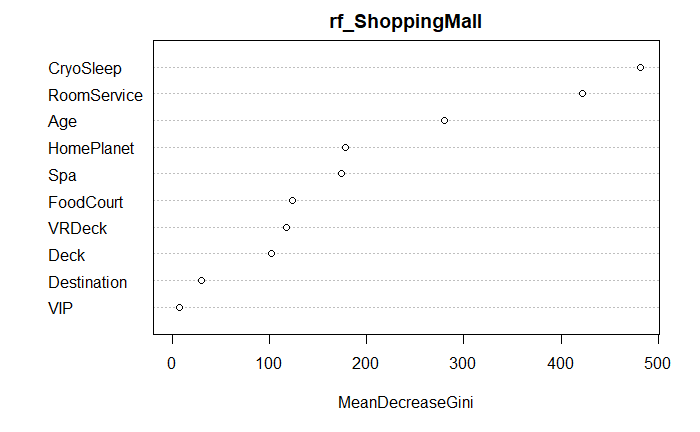

```r
set.seed(42)
rf_ShoppingMall <- randomForest(as.factor(ShoppingMall) ~ ., data = amenities_predictor_train, ntree = 400)
varImpPlot(rf_ShoppingMall, sort=TRUE )
```

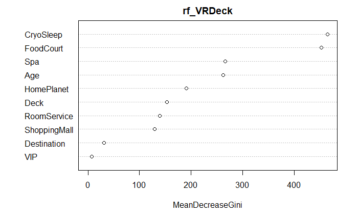

```r
rf_VRDeck <- randomForest(as.factor(VRDeck) ~ ., data = amenities_predictor_train, ntree = 400)
varImpPlot(rf_VRDeck, sort=TRUE )
```

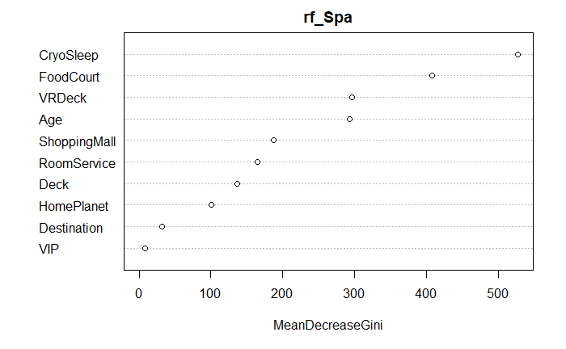

```r
rf_Spa <- randomForest(as.factor(Spa) ~ ., data = amenities_predictor_train, ntree = 400)
varImpPlot(rf_Spa, sort=TRUE )
```

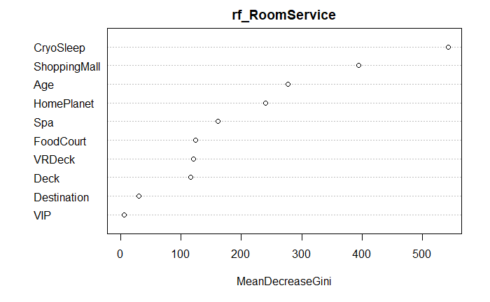

```r
rf_RoomService <- randomForest(as.factor(RoomService) ~ ., data = amenities_predictor_train, ntree = 400)
varImpPlot(rf_RoomService, sort=TRUE )
```

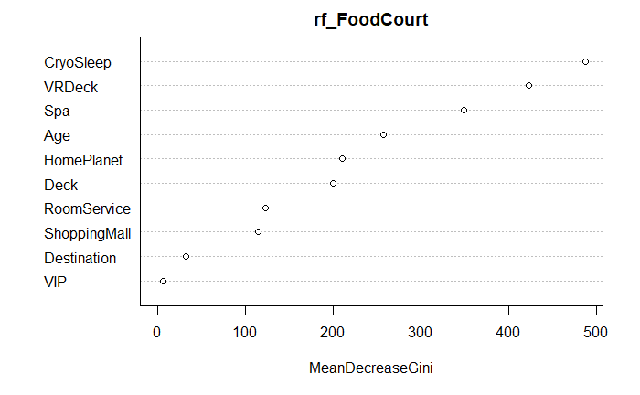

```r
rf_FoodCourt <- randomForest(as.factor(FoodCourt) ~ ., data = amenities_predictor_train, ntree = 400)
varImpPlot(rf_FoodCourt, sort=TRUE)
```

```r
rf_ShoppingMall
```

```
Call:
 randomForest(formula = as.factor(ShoppingMall) ~ ., data = amenities_predictor_train,      ntree = 400)
               Type of random forest: classification
                     Number of trees: 400
No. of variables tried at each split: 3

        OOB estimate of  error rate: 19.6%
Confusion matrix:
     0    1 class.error
0 4522 1053   0.1888789
1  551 2056   0.2113540
```

```r
rf_VRDeck
```

```
Call:
 randomForest(formula = as.factor(VRDeck) ~ ., data = amenities_predictor_train,      ntree = 400)
               Type of random forest: classification
                     Number of trees: 400
No. of variables tried at each split: 3

        OOB estimate of  error rate: 17.12%
Confusion matrix:
     0    1 class.error
0 4363 1094   0.2004765
1  307 2418   0.1126606
```

```r
rf_Spa
```

```
Call:
 randomForest(formula = as.factor(Spa) ~ ., data = amenities_predictor_train,      ntree = 400)
               Type of random forest: classification
                     Number of trees: 400
No. of variables tried at each split: 3

        OOB estimate of  error rate: 20.3%
Confusion matrix:
     0    1 class.error
0 3878 1413  0.26705727
1  248 2643  0.08578347
```

```r
rf_RoomService
```

```
Call:
 randomForest(formula = as.factor(RoomService) ~ ., data = amenities_predictor_train,      ntree = 400)
               Type of random forest: classification
                     Number of trees: 400
No. of variables tried at each split: 3

        OOB estimate of  error rate: 19.45%
Confusion matrix:
     0    1 class.error
0 4562  980   0.1768315
1  611 2029   0.2314394
```

```r
rf_FoodCourt
```

```
Call:
 randomForest(formula = as.factor(FoodCourt) ~ ., data = amenities_predictor_train,      ntree = 400)
               Type of random forest: classification
                     Number of trees: 400
No. of variables tried at each split: 3

        OOB estimate of  error rate: 17.31%
Confusion matrix:
     0    1 class.error
0 4372 1053   0.1941014
1  363 2394   0.1316649
```

#### Plotting results.

We can see that the model does, in fact, predict the amenities with an accuracy of around 80%. We can also note that the model is not just predicting every amenity to be 0, by looking at the 1s accuracy rate (in green) and the 0s accuracy rate (in red).

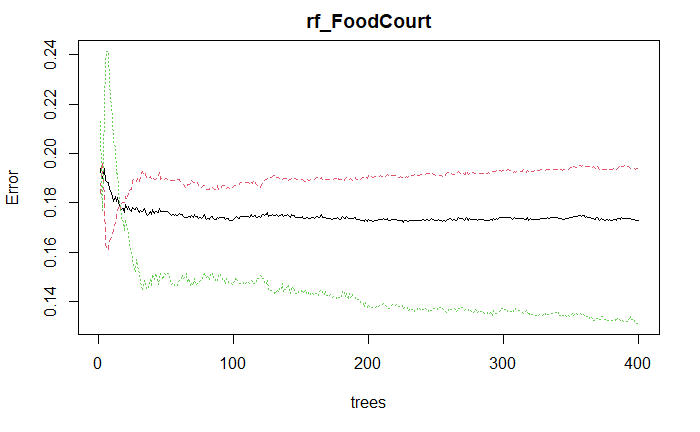

```r
plot(rf_FoodCourt)
```

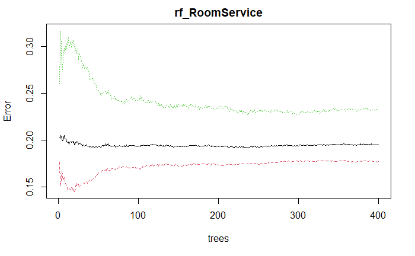

```r
plot(rf_RoomService)
```

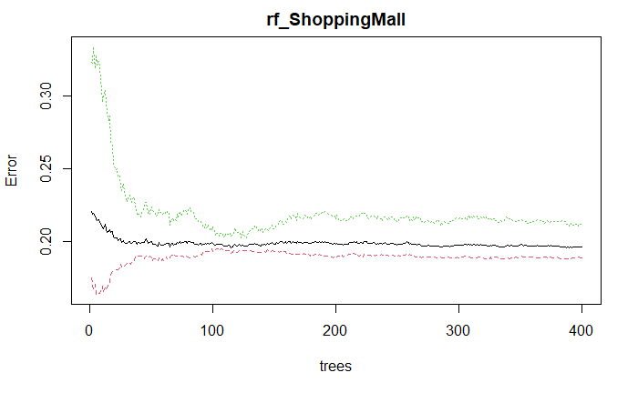

```r
plot(rf_ShoppingMall)
```

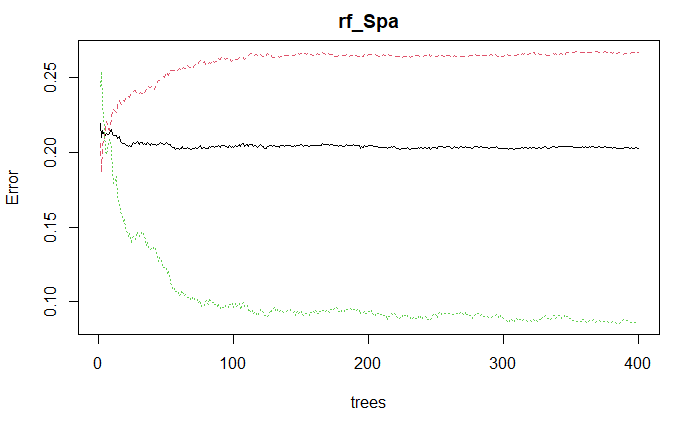

```r
plot(rf_Spa)
```

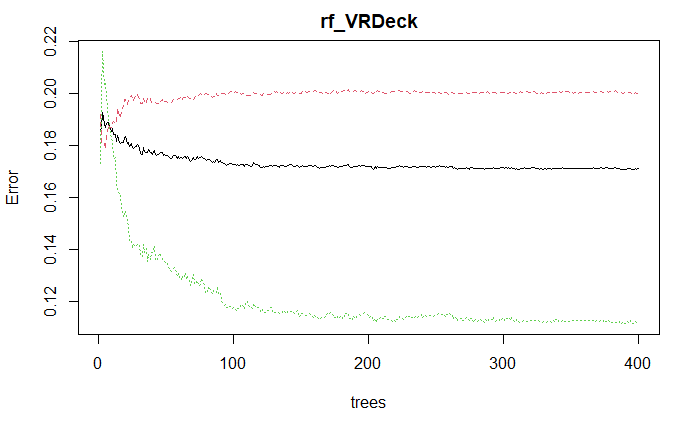

```r
plot(rf_VRDeck)
```

#### Step 4: Imputing with RandomForest

We predict whether a passenger has used or not a specific amenity

```r
pred_roomService <- as.numeric(predict(rf_RoomService, subset(train_bin_am_na, select=-c(RoomService))))
pred_vrdeck <- as.numeric(predict(rf_VRDeck, subset(train_bin_am_na, select=-c(VRDeck))))
pred_spa <- as.numeric(predict(rf_Spa, subset(train_bin_am_na, select=-c(Spa))))
pred_shoppingMall <- as.numeric(predict(rf_ShoppingMall, subset(train_bin_am_na, select=-c(ShoppingMall))))
pred_foodCourt <- as.numeric(predict(rf_FoodCourt, subset(train_bin_am_na, select=-c(FoodCourt))))
```

Based on the prediction of the random forest models, we replace the NA values in the dataset containing the binary values for the amenities with the imputed results given by the models

```r
library(dplyr)

imputed_bin_train <- train_bin_am_na

sapply(imputed_bin_train, function(x) sum(is.na(x)))
```

```
 PassengerId      GroupId IndividualId   HomePlanet    CryoSleep         Deck   RoomNumber         Side
           0            0            0            0            0            0          199            0
 Destination          Age          VIP  RoomService    FoodCourt ShoppingMall          Spa       VRDeck
           0            0            0          106          106          103          109          106
   Amenities    FirstName     LastName  Transported
         511          200          200            0
```

```r
imputed_bin_train <- imputed_bin_train %>% mutate(RoomService = coalesce(RoomService, pred_roomService),
                       Spa = coalesce(Spa, pred_spa),
                       ShoppingMall = coalesce(ShoppingMall, pred_shoppingMall),
                       VRDeck = coalesce(VRDeck, pred_vrdeck),
                       FoodCourt = coalesce(FoodCourt, pred_foodCourt))

sapply(imputed_bin_train, function(x) sum(is.na(x)))
```

```
 PassengerId      GroupId IndividualId   HomePlanet    CryoSleep         Deck   RoomNumber         Side
           0            0            0            0            0            0          199            0
 Destination          Age          VIP  RoomService    FoodCourt ShoppingMall          Spa       VRDeck
           0            0            0            9            8            6            7            8
   Amenities    FirstName     LastName  Transported
         511          200          200            0
```

We drop the still remaining missing values

```r
imputed_bin_train <- train_bin_am %>% drop_na(RoomService, FoodCourt, VRDeck, ShoppingMall, Spa)
```

#### Step 5: Imputing 1s with Linear Regression

We try to predict the correct spending for each passenger

```r
library(MASS)
amenities_imp_train = subset(train, select=-c(PassengerId, Transported, FirstName, CryoSleep, LastName, Amenities, RoomNumber, GroupId, IndividualId))
amenities_imp_train <- filter(amenities_imp_train,  RoomService > 0 , FoodCourt > 0, ShoppingMall > 0, Spa > 0, VRDeck > 0, Age > 13 )

amenities_imp_train %>% mutate(across(where(is.numeric), scale))
```

| HomePlanet | Deck | Side | Destination | Age | VIP | RoomService | FoodCourt | ShoppingMall | Spa | VRDeck |
| --- | --- | --- | --- | --- | --- | --- | --- | --- | --- | --- |
| Earth | G | 0.9130509 | PSO J318.5-22 | 1.19517227 | -0.2150031 | -0.36581614 | -0.3606042521 | -0.30566695 | -0.4416831848 | -0.407123933 |
| Europa | A | -1.0908130 | 55 Cancri e | 2.66818415 | -0.2150031 | -0.42623268 | 0.0611766742 | -0.46061810 | 1.2728100643 | -0.441391466 |
| Earth | F | 0.9130509 | PSO J318.5-22 | -0.76884356 | -0.2150031 | -0.28603533 | -0.3624261999 | -0.37298179 | -0.4546840815 | -0.446495141 |
| Europa | A | 0.9130509 | TRAPPIST-1e | 0.86783630 | -0.2150031 | -0.43940038 | 0.4642826350 | -0.42378545 | -0.4519755613 | -0.302863139 |
| Earth | F | 0.9130509 | 55 Cancri e | -1.17801353 | -0.2150031 | 0.69844441 | -0.5241240712 | -0.34503978 | 0.1455239817 | -0.206622407 |
| Earth | G | -1.0908130 | PSO J318.5-22 | -0.68700957 | -0.2150031 | -0.31701817 | -0.5418880627 | -0.41616490 | -0.1562051620 | -0.446495141 |
| Earth | G | -1.0908130 | 55 Cancri e | -0.93251155 | -0.2150031 | -0.39370069 | -0.4594449227 | -0.18373818 | -0.3680114370 | -0.403478450 |
| Earth | F | -1.0908130 | TRAPPIST-1e | -0.93251155 | -0.2150031 | -0.34102987 | -0.5027161840 | -0.11007288 | -0.3560939484 | -0.434100501 |
| Earth | F | 0.9130509 | TRAPPIST-1e | -0.68700957 | -0.2150031 | -0.35652129 | -0.5468984193 | -0.43394618 | -0.1578302740 | -0.415143994 |
| Earth | F | 0.9130509 | TRAPPIST-1e | -1.34168152 | -0.2150031 | -0.20625451 | -0.5191137147 | -0.27391467 | -0.1491630096 | -0.445766045 |

[output cut: 238 more lines]

```r
room_imp = lm(RoomService~.,data= amenities_imp_train)
food_imp = lm(FoodCourt~.,data= amenities_imp_train)
shopping_mall_imp = lm(ShoppingMall~.,data= amenities_imp_train,)
spa_imp = lm(Spa~.,data= amenities_imp_train)
vr_imp = lm(VRDeck~.,data= amenities_imp_train)


head(amenities_imp_train)
```

|  | HomePlanet | Deck | Side | Destination | Age | VIP | RoomService | FoodCourt | ShoppingMall | Spa | VRDeck |
| --- | --- | --- | --- | --- | --- | --- | --- | --- | --- | --- | --- |
| 1 | Earth | G | 1 | PSO J318.5-22 | 47 | 0 | 97 | 418 | 126 | 25 | 55 |
| 2 | Europa | A | 0 | 55 Cancri e | 65 | 0 | 19 | 1344 | 4 | 3190 | 8 |
| 3 | Earth | F | 1 | PSO J318.5-22 | 23 | 0 | 200 | 414 | 73 | 1 | 1 |
| 4 | Europa | A | 1 | TRAPPIST-1e | 43 | 0 | 2 | 2229 | 33 | 6 | 198 |
| 5 | Earth | F | 1 | 55 Cancri e | 18 | 0 | 1471 | 59 | 95 | 1109 | 330 |
| 6 | Earth | G | 0 | PSO J318.5-22 | 24 | 0 | 160 | 20 | 39 | 552 | 1 |

```r
summary(room_imp)
```

```
Call:
lm(formula = RoomService ~ ., data = amenities_imp_train)

Residuals:
    Min      1Q  Median      3Q     Max
-2104.3  -435.7  -159.9   185.6  6857.0

Coefficients:
                           Estimate Std. Error t value Pr(>|t|)
(Intercept)              -7.429e+02  5.917e+02  -1.256 0.210548
HomePlanetEuropa          7.428e+02  4.263e+02   1.743 0.082722 .
HomePlanetMars            9.294e+02  3.022e+02   3.075 0.002358 **
DeckB                     4.047e+02  3.864e+02   1.047 0.296099
DeckC                     1.222e+03  3.753e+02   3.256 0.001300 **
DeckD                    -2.395e+01  4.722e+02  -0.051 0.959603
DeckE                     7.067e+02  4.733e+02   1.493 0.136776
DeckF                     5.905e+02  5.169e+02   1.142 0.254518
DeckG                     6.609e+02  5.512e+02   1.199 0.231737
Side                     -2.073e+02  1.555e+02  -1.333 0.183988
DestinationPSO J318.5-22  1.906e+02  3.651e+02   0.522 0.602035
DestinationTRAPPIST-1e    3.829e+02  1.922e+02   1.992 0.047580 *
Age                       4.635e+00  6.723e+00   0.689 0.491243
VIP                      -5.150e+01  3.945e+02  -0.131 0.896268
FoodCourt                -1.658e-03  4.294e-02  -0.039 0.969228
ShoppingMall              2.681e-04  1.018e-01   0.003 0.997901
Spa                       1.537e-01  4.601e-02   3.341 0.000974 ***
VRDeck                   -1.830e-01  6.187e-02  -2.958 0.003418 **
---
Signif. codes:  0 ‘***’ 0.001 ‘**’ 0.01 ‘*’ 0.05 ‘.’ 0.1 ‘ ’ 1

Residual standard error: 1187 on 230 degrees of freedom
Multiple R-squared:  0.2126,    Adjusted R-squared:  0.1544
F-statistic: 3.653 on 17 and 230 DF,  p-value: 3.612e-06
```

```r
summary(food_imp)
```

```
Call:
lm(formula = FoodCourt ~ ., data = amenities_imp_train)

Residuals:
    Min      1Q  Median      3Q     Max
-3343.6  -488.6  -166.0   268.9 11875.3

Coefficients:
                           Estimate Std. Error t value Pr(>|t|)
(Intercept)              -497.06939  911.04261  -0.546 0.585866
HomePlanetEuropa         2334.93328  640.56414   3.645 0.000330 ***
HomePlanetMars           -138.14184  473.40762  -0.292 0.770700
DeckB                    2220.80654  576.44392   3.853 0.000152 ***
DeckC                    2223.86907  570.84690   3.896 0.000128 ***
DeckD                    2150.16889  711.09550   3.024 0.002780 **
DeckE                    1326.54118  724.94467   1.830 0.068567 .
DeckF                    1497.54715  789.80657   1.896 0.059201 .
DeckG                    1632.02049  842.05879   1.938 0.053831 .
Side                      -67.60981  239.68364  -0.282 0.778136
DestinationPSO J318.5-22 -444.38991  560.09540  -0.793 0.428352
DestinationTRAPPIST-1e   -433.34197  296.33401  -1.462 0.145012
Age                        -4.93342   10.32782  -0.478 0.633330
VIP                       477.77319  604.99471   0.790 0.430508
RoomService                -0.00391    0.10124  -0.039 0.969228
ShoppingMall               -0.37575    0.15432  -2.435 0.015656 *
Spa                        -0.09397    0.07207  -1.304 0.193620
VRDeck                     -0.10466    0.09654  -1.084 0.279463
---
Signif. codes:  0 ‘***’ 0.001 ‘**’ 0.01 ‘*’ 0.05 ‘.’ 0.1 ‘ ’ 1

Residual standard error: 1823 on 230 degrees of freedom
Multiple R-squared:  0.3581,    Adjusted R-squared:  0.3106
F-statistic: 7.547 on 17 and 230 DF,  p-value: 9.873e-15
```

```r
summary(shopping_mall_imp)
```

```
Call:
lm(formula = ShoppingMall ~ ., data = amenities_imp_train)

Residuals:
   Min     1Q Median     3Q    Max
-989.8 -361.1 -144.3  103.4 4278.0

Coefficients:
                           Estimate Std. Error t value Pr(>|t|)
(Intercept)               4.914e+02  3.832e+02   1.282   0.2011
HomePlanetEuropa          6.739e+02  2.744e+02   2.456   0.0148 *
HomePlanetMars            5.841e+02  1.960e+02   2.980   0.0032 **
DeckB                    -5.010e+01  2.509e+02  -0.200   0.8419
DeckC                    -9.707e+01  2.486e+02  -0.391   0.6965
DeckD                    -1.153e+02  3.058e+02  -0.377   0.7065
DeckE                     2.364e+02  3.077e+02   0.768   0.4430
DeckF                     1.926e+01  3.358e+02   0.057   0.9543
DeckG                     1.831e+02  3.579e+02   0.511   0.6095
Side                     -7.267e+01  1.010e+02  -0.719   0.4726
DestinationPSO J318.5-22 -1.205e+02  2.365e+02  -0.510   0.6109
DestinationTRAPPIST-1e   -9.081e+00  1.256e+02  -0.072   0.9424
Age                      -9.860e+00  4.311e+00  -2.287   0.0231 *
VIP                      -7.007e+01  2.555e+02  -0.274   0.7842
RoomService               1.125e-04  4.271e-02   0.003   0.9979
FoodCourt                -6.688e-02  2.747e-02  -2.435   0.0157 *
Spa                      -2.766e-03  3.052e-02  -0.091   0.9279
VRDeck                   -4.187e-02  4.074e-02  -1.028   0.3052
---
Signif. codes:  0 ‘***’ 0.001 ‘**’ 0.01 ‘*’ 0.05 ‘.’ 0.1 ‘ ’ 1

Residual standard error: 769 on 230 degrees of freedom
Multiple R-squared:  0.1116,    Adjusted R-squared:  0.04596
F-statistic:   1.7 on 17 and 230 DF,  p-value: 0.04384
```

```r
summary(spa_imp)
```

```
Call:
lm(formula = Spa ~ ., data = amenities_imp_train)

Residuals:
    Min      1Q  Median      3Q     Max
-3649.2  -679.2  -140.9   158.6 10086.7

Coefficients:
                           Estimate Std. Error t value Pr(>|t|)
(Intercept)              -3.833e+01  8.310e+02  -0.046 0.963245
HomePlanetEuropa          1.215e+03  5.951e+02   2.042 0.042340 *
HomePlanetMars           -1.210e+02  4.315e+02  -0.280 0.779466
DeckB                     1.279e+03  5.355e+02   2.388 0.017730 *
DeckC                     4.161e+02  5.365e+02   0.775 0.438866
DeckD                     6.712e+02  6.595e+02   1.018 0.309839
DeckE                     4.101e+02  6.650e+02   0.617 0.538100
DeckF                     5.393e+02  7.247e+02   0.744 0.457547
DeckG                     5.058e+02  7.731e+02   0.654 0.513558
Side                      1.010e+02  2.184e+02   0.463 0.644069
DestinationPSO J318.5-22  2.458e+02  5.110e+02   0.481 0.630987
DestinationTRAPPIST-1e   -5.577e+02  2.689e+02  -2.074 0.039162 *
Age                       2.507e+00  9.417e+00   0.266 0.790302
VIP                       8.519e+02  5.493e+02   1.551 0.122349
RoomService               3.011e-01  9.013e-02   3.341 0.000974 ***
FoodCourt                -7.807e-02  5.988e-02  -1.304 0.193620
ShoppingMall             -1.291e-02  1.425e-01  -0.091 0.927861
VRDeck                    3.047e-03  8.823e-02   0.035 0.972484
---
Signif. codes:  0 ‘***’ 0.001 ‘**’ 0.01 ‘*’ 0.05 ‘.’ 0.1 ‘ ’ 1

Residual standard error: 1662 on 230 degrees of freedom
Multiple R-squared:  0.2456,    Adjusted R-squared:  0.1898
F-statistic: 4.405 on 17 and 230 DF,  p-value: 7.398e-08
```

```r
summary(vr_imp)
```

```
Call:
lm(formula = VRDeck ~ ., data = amenities_imp_train)

Residuals:
    Min      1Q  Median      3Q     Max
-2103.6  -356.4  -109.9   213.2 10736.6

Coefficients:
                           Estimate Std. Error t value Pr(>|t|)
(Intercept)               6.161e+02  6.197e+02   0.994  0.32123
HomePlanetEuropa          9.597e+02  4.443e+02   2.160  0.03181 *
HomePlanetMars            3.758e+02  3.216e+02   1.168  0.24384
DeckB                    -3.212e+02  4.046e+02  -0.794  0.42804
DeckC                     7.044e+02  3.988e+02   1.766  0.07867 .
DeckD                    -4.336e+02  4.931e+02  -0.879  0.38014
DeckE                    -3.922e+02  4.968e+02  -0.789  0.43065
DeckF                    -4.166e+02  5.415e+02  -0.769  0.44250
DeckG                    -3.576e+02  5.778e+02  -0.619  0.53661
Side                     -1.771e+02  1.629e+02  -1.087  0.27808
DestinationPSO J318.5-22  5.644e+01  3.821e+02   0.148  0.88269
DestinationTRAPPIST-1e    7.733e+01  2.027e+02   0.381  0.70324
Age                       1.565e+00  7.039e+00   0.222  0.82427
VIP                      -3.613e+01  4.127e+02  -0.088  0.93031
RoomService              -2.003e-01  6.770e-02  -2.958  0.00342 **
FoodCourt                -4.857e-02  4.481e-02  -1.084  0.27946
ShoppingMall             -1.092e-01  1.062e-01  -1.028  0.30518
Spa                       1.702e-03  4.928e-02   0.035  0.97248
---
Signif. codes:  0 ‘***’ 0.001 ‘**’ 0.01 ‘*’ 0.05 ‘.’ 0.1 ‘ ’ 1

Residual standard error: 1242 on 230 degrees of freedom
Multiple R-squared:  0.2367,    Adjusted R-squared:  0.1802
F-statistic: 4.194 on 17 and 230 DF,  p-value: 2.199e-07
```

We see that the explainability for the linear regression is very low, with R^2 values as low as 11%.

Just to try it out, we wanted to see if a poisson linear regression would fit the data better.

```r
library(msme)
amenities_imp_train = subset(train, select=-c(PassengerId, Transported, FirstName, CryoSleep, LastName, Amenities, RoomNumber, GroupId, IndividualId))
amenities_imp_train <- filter(amenities_imp_train,  RoomService > 0 , FoodCourt > 0, ShoppingMall > 0, Spa > 0, VRDeck > 0, Age > 13 )

amenities_imp_train %>% mutate(across(where(is.numeric), scale))
```

| HomePlanet | Deck | Side | Destination | Age | VIP | RoomService | FoodCourt | ShoppingMall | Spa | VRDeck |
| --- | --- | --- | --- | --- | --- | --- | --- | --- | --- | --- |
| Earth | G | 0.9130509 | PSO J318.5-22 | 1.19517227 | -0.2150031 | -0.36581614 | -0.3606042521 | -0.30566695 | -0.4416831848 | -0.407123933 |
| Europa | A | -1.0908130 | 55 Cancri e | 2.66818415 | -0.2150031 | -0.42623268 | 0.0611766742 | -0.46061810 | 1.2728100643 | -0.441391466 |
| Earth | F | 0.9130509 | PSO J318.5-22 | -0.76884356 | -0.2150031 | -0.28603533 | -0.3624261999 | -0.37298179 | -0.4546840815 | -0.446495141 |
| Europa | A | 0.9130509 | TRAPPIST-1e | 0.86783630 | -0.2150031 | -0.43940038 | 0.4642826350 | -0.42378545 | -0.4519755613 | -0.302863139 |
| Earth | F | 0.9130509 | 55 Cancri e | -1.17801353 | -0.2150031 | 0.69844441 | -0.5241240712 | -0.34503978 | 0.1455239817 | -0.206622407 |
| Earth | G | -1.0908130 | PSO J318.5-22 | -0.68700957 | -0.2150031 | -0.31701817 | -0.5418880627 | -0.41616490 | -0.1562051620 | -0.446495141 |
| Earth | G | -1.0908130 | 55 Cancri e | -0.93251155 | -0.2150031 | -0.39370069 | -0.4594449227 | -0.18373818 | -0.3680114370 | -0.403478450 |
| Earth | F | -1.0908130 | TRAPPIST-1e | -0.93251155 | -0.2150031 | -0.34102987 | -0.5027161840 | -0.11007288 | -0.3560939484 | -0.434100501 |
| Earth | F | 0.9130509 | TRAPPIST-1e | -0.68700957 | -0.2150031 | -0.35652129 | -0.5468984193 | -0.43394618 | -0.1578302740 | -0.415143994 |
| Earth | F | 0.9130509 | TRAPPIST-1e | -1.34168152 | -0.2150031 | -0.20625451 | -0.5191137147 | -0.27391467 | -0.1491630096 | -0.445766045 |

[output cut: 238 more lines]

```r
room_imp = glm(RoomService~.,data= amenities_imp_train, family="poisson")
food_imp = glm(FoodCourt~.,data= amenities_imp_train, family="poisson")
shopping_mall_imp = glm(ShoppingMall~.,data= amenities_imp_train, family="poisson")
spa_imp = glm(Spa~.,data= amenities_imp_train, family="poisson")
vr_imp = glm(VRDeck~.,data= amenities_imp_train, family="poisson")

P__disp(room_imp)
```

```
pearson.chi2   dispersion
  315363.550     1371.146
```

```r
P__disp(food_imp)
```

```
pearson.chi2   dispersion
  349306.470     1518.724
```

```r
P__disp(shopping_mall_imp)
```

```
pearson.chi2   dispersion
  252566.209     1098.114
```

```r
P__disp(spa_imp)
```

```
pearson.chi2   dispersion
  428929.455     1864.911
```

```r
P__disp(vr_imp)
```

```
pearson.chi2   dispersion
  254724.627     1107.498
```

Even using a linear model with the poisson distribution doesn’t yield acceptable results. There is, in fact, a very high dispersion, which means that the model didn’t fit the data in an optimal way.

This is when we decided that we needed to discard this strategy.

### Strategy 2: Random Forest Regressor

We therefore decided to directly train a random forest regressor, in order to see if the performances would be better than the binary values approach.

```r
train_rf_reg <- train %>% drop_na(RoomService, FoodCourt, VRDeck, ShoppingMall, Spa)
amenities_predictor_train = subset(train_rf_reg, select=-c(Transported, FirstName, LastName, Amenities, RoomNumber, GroupId, IndividualId, Side))

# check
sapply(amenities_predictor_train, function(x) sum(is.na(x)))
```

```
 PassengerId   HomePlanet    CryoSleep         Deck  Destination          Age          VIP  RoomService
           0            0            0            0            0            0            0            0
   FoodCourt ShoppingMall          Spa       VRDeck
           0            0            0            0
```

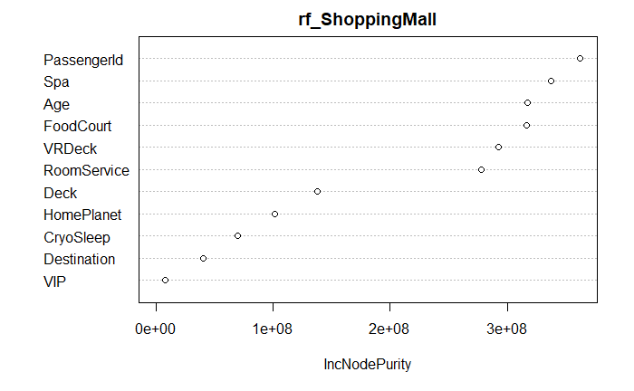

```r
set.seed(42)
rf_ShoppingMall <- randomForest(ShoppingMall ~ ., data = amenities_predictor_train, ntree = 400)
varImpPlot(rf_ShoppingMall, sort=TRUE )
```

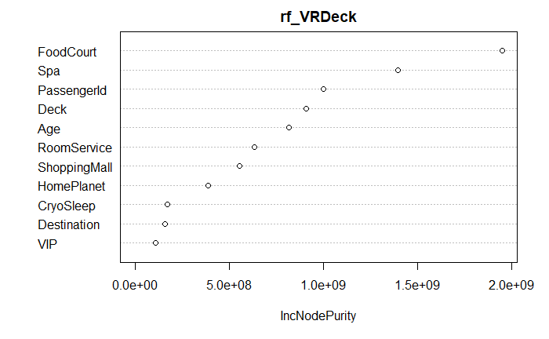

```r
rf_VRDeck <- randomForest(VRDeck ~ ., data = amenities_predictor_train, ntree = 400)
varImpPlot(rf_VRDeck, sort=TRUE )
```

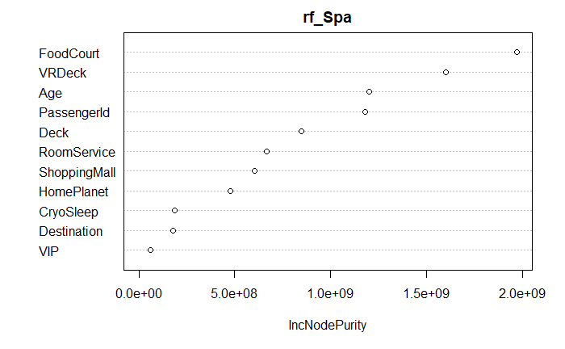

```r
rf_Spa <- randomForest(Spa ~ ., data = amenities_predictor_train, ntree = 400)
varImpPlot(rf_Spa, sort=TRUE )
```

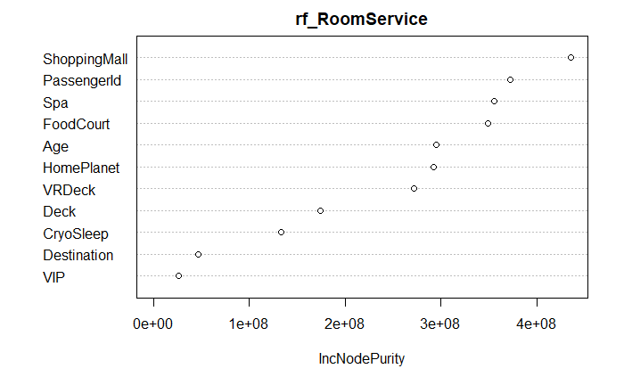

```r
rf_RoomService <- randomForest(RoomService ~ ., data = amenities_predictor_train, ntree = 400)
varImpPlot(rf_RoomService, sort=TRUE )
```

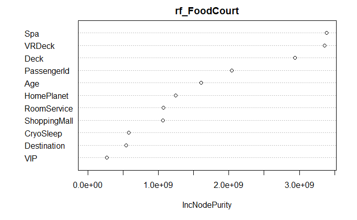

```r
rf_FoodCourt <- randomForest(FoodCourt ~ ., data = amenities_predictor_train, ntree = 400)
varImpPlot(rf_FoodCourt, sort=TRUE)
```

```r
rf_ShoppingMall
```

```
Call:
 randomForest(formula = ShoppingMall ~ ., data = amenities_predictor_train,      ntree = 400)
               Type of random forest: regression
                     Number of trees: 400
No. of variables tried at each split: 3

          Mean of squared residuals: 264993
                    % Var explained: 20.02
```

```r
rf_VRDeck
```

```
Call:
 randomForest(formula = VRDeck ~ ., data = amenities_predictor_train,      ntree = 400)
               Type of random forest: regression
                     Number of trees: 400
No. of variables tried at each split: 3

          Mean of squared residuals: 810645.5
                    % Var explained: 30.26
```

```r
rf_Spa
```

```
Call:
 randomForest(formula = Spa ~ ., data = amenities_predictor_train,      ntree = 400)
               Type of random forest: regression
                     Number of trees: 400
No. of variables tried at each split: 3

          Mean of squared residuals: 972296.5
                    % Var explained: 24.01
```

```r
rf_RoomService
```

```
Call:
 randomForest(formula = RoomService ~ ., data = amenities_predictor_train,      ntree = 400)
               Type of random forest: regression
                     Number of trees: 400
No. of variables tried at each split: 3

          Mean of squared residuals: 286180.5
                    % Var explained: 29.85
```

```r
rf_FoodCourt
```

```
Call:
 randomForest(formula = FoodCourt ~ ., data = amenities_predictor_train,      ntree = 400)
               Type of random forest: regression
                     Number of trees: 400
No. of variables tried at each split: 3

          Mean of squared residuals: 1525221
                    % Var explained: 40.4
```

During the presentation we gave internally about this report, we did not notice an error which was making us use a random forest classifier instead of a regressor, leading us to believe this strategy was roughly equivalent to what we ended up selecting anyway, i.e. k-nearest-neighbor imputation.

We noticed the inconsistency when checking what another galactic library was achieving, much worse results, and confirmed it when trying to plot a confusion matrix and realizing almost every point was considered as a separate class.

### Strategy 3: Imputing with KNN

We can see that the Random Forest Regressor looks similar to the regular linear regression. We are therefore going to try with a different approach and train a KNN model to see if it able to fit the data any better.

In the following sections, we are going to train a KNN model which will predict the value of a single amenity.

```r
# We chose a dataset with no missing amenities
train_no_missing_amenities <-
  filter(train,  !is.na(RoomService), !is.na(FoodCourt), !is.na(ShoppingMall),
         !is.na(Spa), !is.na(VRDeck))


knn_trial <- train_no_missing_amenities
knn_trial <- knn_trial %>% mutate(value = 1)  %>% spread(HomePlanet, value,  fill = 0 )
knn_trial <- subset(knn_trial, select=-c(PassengerId, IndividualId, GroupId, Amenities, Deck, RoomNumber, Side, Destination, FirstName, LastName))


#A function to normalize the data
normalize <- function(x) {
return ((x - min(x)) / (max(x) - min(x))) }

# We normalize the data except for RoomService and we store the new values in the knn_trial.n variable
knn_trial.n <- as.data.frame(lapply(subset(knn_trial, select=-c(ShoppingMall)), normalize))


#We split into train and test
set.seed(42)

data.knn <- sample(1:nrow(knn_trial.n),size=nrow(knn_trial.n)*0.7,replace = FALSE) #random selection of 70% data.

knn.train <- knn_trial.n[data.knn ,] # 70% training data
knn.test <- knn_trial.n[-data.knn ,] # remaining 30% test data

knn.train_labels <- subset(knn_trial, select=c(ShoppingMall))[data.knn,1]
knn.test_labels <- subset(knn_trial, select=c(ShoppingMall))[-data.knn,1]
```

Now that the pre-processing is done, we move onto the creation of the model.

First we need to choose a meaningful number of neighbors as a hyper-parameter to our model.

In order to do so, it is good practice to choose the square root of the number of data points at our disposal.

```r
library(class)
NROW(knn.train_labels)
```

```
[1] 5727
```

The square root is around 75.6, so we can make two models, one with 75 neighbors and the other one with 76 and compare their performances.

```r
knn.75 <- knn(train=knn.train, test=knn.test, cl=knn.train_labels, k=75)
knn.76 <- knn(train=knn.train, test=knn.test, cl=knn.train_labels, k=76)
```

```r
ACC.75 <- 100 * sum(knn.test_labels == knn.75)/NROW(knn.test_labels)
ACC.76 <- 100 * sum(knn.test_labels == knn.76)/NROW(knn.test_labels)

ACC.75
```

```
[1] 68.30957
```

```r
ACC.76
```

```
[1] 68.30957
```

Here we take care of the actual imputation. Before doing that, we wanted to check the distribution of the imputed variables.

```r
train_knn <- train
sapply(train_knn, function(x) sum(is.na(x)))
```

```
 PassengerId      GroupId IndividualId   HomePlanet    CryoSleep         Deck   RoomNumber         Side
           0            0            0            0            0            0          199            0
 Destination          Age          VIP  RoomService    FoodCourt ShoppingMall          Spa       VRDeck
           0            0            0          106          106          103          109          106
   Amenities    FirstName     LastName  Transported
         511          200          200            0
```

```r
model <- preProcess(train_knn[,c('RoomService', 'FoodCourt', 'ShoppingMall', 'Spa', 'VRDeck', 'Deck')], method='knnImpute')
model_predict <- filter(train,  is.na(RoomService) | is.na(FoodCourt) | is.na(ShoppingMall) | is.na(Spa) | is.na(VRDeck))
model_predict <- predict(model, newdata = model_predict)


procNames <- data.frame(col = names(model$mean), mean = model$mean, sd = model$std)

for(i in procNames$col){
  model_predict[i] <- model_predict[i]*model$std[i]+model$mean[i]
}

model_predict
```

| PassengerId | GroupId | IndividualId | HomePlanet | CryoSleep | Deck | RoomNumber | Side | Destination | Age | VIP | RoomService | FoodCourt | ShoppingMall | Spa | VRDeck | Amenities | FirstName | LastName | Transported |
| --- | --- | --- | --- | --- | --- | --- | --- | --- | --- | --- | --- | --- | --- | --- | --- | --- | --- | --- | --- |
| 0890_01 | 890 | 1 | Mars | 0 | F | 184 | 0 | TRAPPIST-1e | 16 | 0 | 1.720000e+02 | 256.8 | 338.0 | 9.000000e+00 | 0.0 | NA | NA | NA | 0 |
| 1829_01 | 1829 | 1 | Europa | 0 | D | 56 | 0 | 55 Cancri e | 48 | 0 | -2.842171e-14 | 3578.0 | 80.0 | 1.230000e+02 | 1152.0 | NA | NA | NA | 1 |
| 3315_01 | 3315 | 1 | Earth | 0 | F | 627 | 1 | TRAPPIST-1e | 15 | 0 | 1.000000e+01 | 0.0 | 99.0 | 4.354000e+02 | 2031.0 | NA | NA | NA | 0 |
| 4160_01 | 4160 | 1 | Mars | 0 | F | 783 | 1 | TRAPPIST-1e | 27 | 1 | 6.610000e+02 | 349.6 | 991.0 | 4.600000e+01 | 0.0 | NA | NA | NA | 1 |
| 5977_02 | 5977 | 2 | Europa | 0 | B | 230 | 1 | 55 Cancri e | 57 | 0 | 2.000000e+02 | 9.0 | 0.0 | 1.285200e+03 | 24133.0 | NA | NA | NA | 0 |
| 9034_04 | 9034 | 4 | Europa | 0 | D | 288 | 0 | TRAPPIST-1e | 60 | 0 | -2.842171e-14 | 1906.0 | 947.0 | 6.680000e+02 | 1.0 | NA | NA | NA | 1 |
| 0014_01 | 14 | 1 | Mars | 0 | F | 3 | 0 | 55 Cancri e | 27 | 0 | 1.286000e+03 | 122.0 | 12.6 | 5.684342e-14 | 0.0 | NA | Flats | Eccle | 0 |
| 0031_03 | 31 | 3 | Mars | 0 | F | 9 | 0 | TRAPPIST-1e | 20 | 0 | 3.034000e+02 | 0.0 | 1750.0 | 9.900000e+02 | 0.0 | NA | Dontch | Datie | 1 |
| 0050_01 | 50 | 1 | Earth | 0 | E | 1 | 1 | 55 Cancri e | 35 | 0 | 7.900000e+02 | 0.0 | 0.0 | 1.138000e+02 | 0.0 | NA | Sony | Lancis | 0 |
| 0103_01 | 103 | 1 | Earth | 0 | F | 24 | 1 | TRAPPIST-1e | 24 | 0 | -2.842171e-14 | 3085.6 | 0.0 | 5.684342e-14 | 17.0 | NA | Arlen | Mclainez | 1 |

[output cut: 501 more lines]

We verified that the new values imputed by KNN will follow similar distributions to the ones with missing values presented in the next section of the document, the two can be compared graphically.

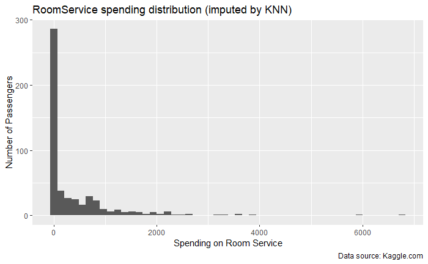

```r
ggplot(model_predict,mapping = aes(x=RoomService)) +
                 geom_histogram(bins = 50) +
                 labs(x = "Spending on Room Service",
                      y = "Number of Passengers",
                      title = "RoomService spending distribution (imputed by KNN)",
                      caption = "Data source: Kaggle.com")
```

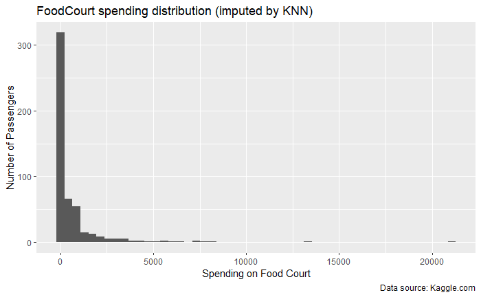

```r
ggplot(model_predict,mapping = aes(x=FoodCourt)) +
                 geom_histogram(bins = 50) +
                 labs(x = "Spending on Food Court",
                      y = "Number of Passengers",
                      title = "FoodCourt spending distribution (imputed by KNN)",
                      caption = "Data source: Kaggle.com")
```

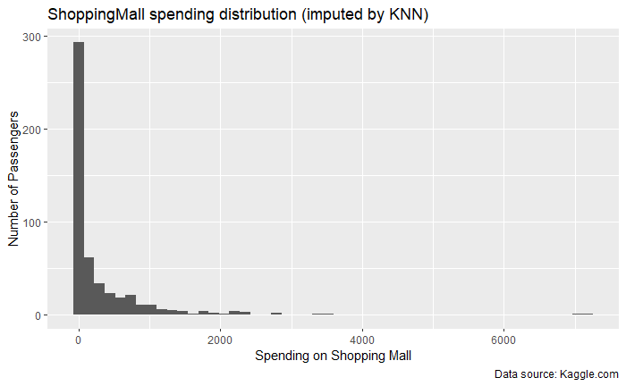

```r
ggplot(model_predict,mapping = aes(x=ShoppingMall)) +
                 geom_histogram(bins = 50) +
                 labs(x = "Spending on Shopping Mall",
                      y = "Number of Passengers",
                      title = "ShoppingMall spending distribution (imputed by KNN)",
                      caption = "Data source: Kaggle.com")
```

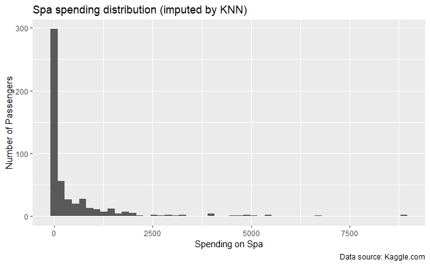

```r
ggplot(model_predict,mapping = aes(x=Spa)) +
                 geom_histogram(bins = 50) +
                 labs(x = "Spending on Spa",
                      y = "Number of Passengers",
                      title = "Spa spending distribution (imputed by KNN)",
                      caption = "Data source: Kaggle.com")
```

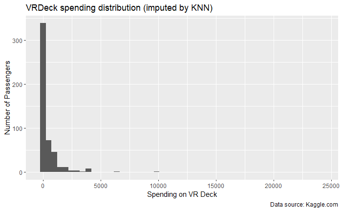

```r
ggplot(model_predict,mapping = aes(x=VRDeck)) +
                 geom_histogram(bins = 50) +
                 labs(x = "Spending on VR Deck",
                      y = "Number of Passengers",
                      title = "VRDeck spending distribution (imputed by KNN)",
                      caption = "Data source: Kaggle.com")
```

The distributions look fairly similar to the original ones.

We can now substitute into the original dataset the values imputed by KNN. The function that we just used, with KNN impute, gives us back a normalized version of our features. We want, however, to denormalize them to be able to use them later for predicting Transported.

```r
sapply(train, function(x) sum(is.na(x)))
```

```
 PassengerId      GroupId IndividualId   HomePlanet    CryoSleep         Deck   RoomNumber         Side
           0            0            0            0            0            0          199            0
 Destination          Age          VIP  RoomService    FoodCourt ShoppingMall          Spa       VRDeck
           0            0            0          106          106          103          109          106
   Amenities    FirstName     LastName  Transported
         511          200          200            0
```

```r
#Imputing the missing values
imputed_knn <- predict(model, newdata = train)

procNames <- data.frame(col = names(model$mean), mean = model$mean, sd = model$std)
for(i in procNames$col){
 train_knn[i] <- imputed_knn[i]*model$std[i]+model$mean[i]
}

train_knn$RoomService <- as.numeric(format(train_knn$RoomService))
```

The last thing that we need to do is to calculate Amenities for the newly imputed values.

```r
train_knn$Amenities = train_knn$RoomService + train_knn$FoodCourt + train_knn$ShoppingMall + train_knn$Spa + train_knn$VRDeck
```

And finally, use the newly imputed data as train

```r
train <- train_knn
```

# Exploratory data analysis (EDA):

Let’s start looking at the numerical distributions in our data-set:

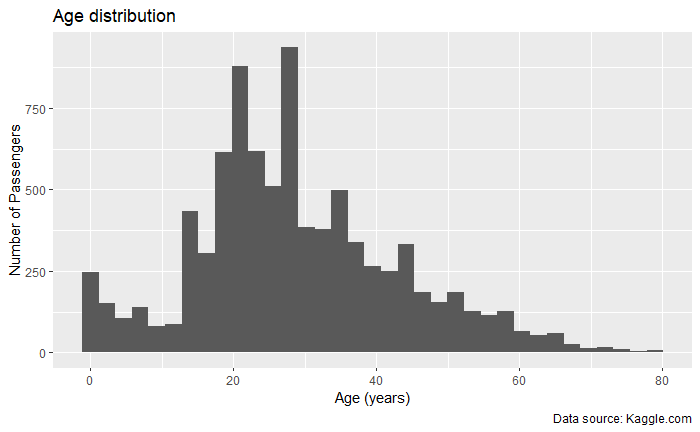

```r
ggplot(train) +
      geom_histogram(mapping = aes(x=Age), bins=35) +
      labs(x = "Age (years)",
           y = "Number of Passengers",
           title = "Age distribution",
           caption = "Data source: Kaggle.com")
```

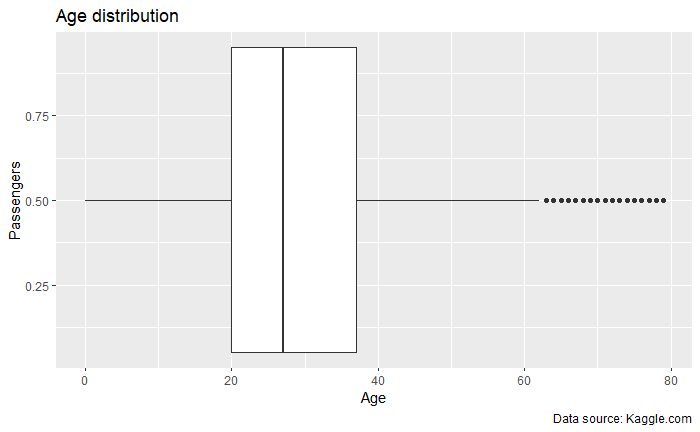

```r
ggplot(train) +
  geom_boxplot(mapping = aes(x=Transported, y=Age)) +
  coord_flip() +
        labs(x = "Passengers",
           y = "Age",
           title = "Age distribution",
           caption = "Data source: Kaggle.com")
```

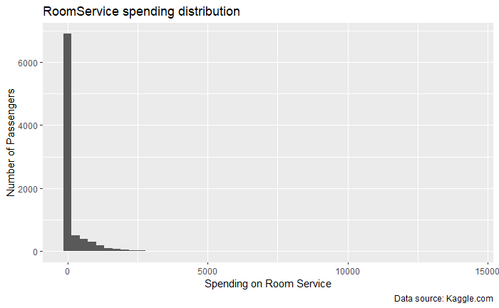

```r
ggplot(train,mapping = aes(x=RoomService)) +
                 geom_histogram(bins = 50) +
                 labs(x = "Spending on Room Service",
                      y = "Number of Passengers",
                      title = "RoomService spending distribution",
                      caption = "Data source: Kaggle.com")
```

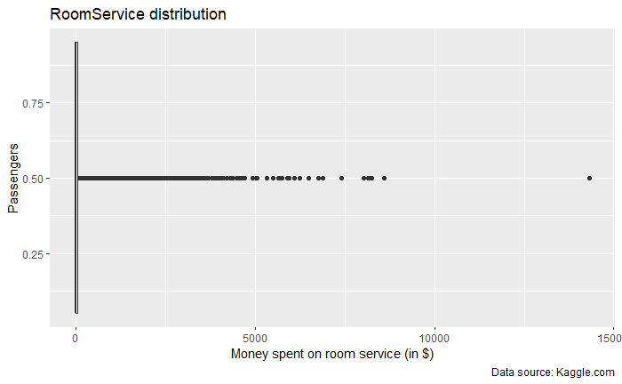

```r
ggplot(train) +
  geom_boxplot(mapping = aes(x=Transported, y=RoomService)) +
  coord_flip() +
        labs(x = "Passengers",
           y = "Money spent on room service (in $)",
           title = "RoomService distribution",
           caption = "Data source: Kaggle.com")
```

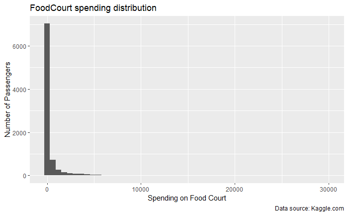

```r
ggplot(train,mapping = aes(x=FoodCourt)) +
                 geom_histogram(bins = 50) +
                 labs(x = "Spending on Food Court",
                      y = "Number of Passengers",
                      title = "FoodCourt spending distribution",
                      caption = "Data source: Kaggle.com")
```

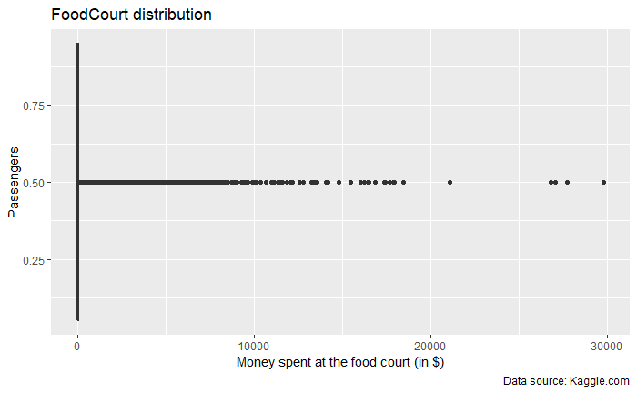

```r
ggplot(train) +
  geom_boxplot(mapping = aes(x=Transported, y=FoodCourt)) +
  coord_flip() +
        labs(x = "Passengers",
           y = "Money spent at the food court (in $)",
           title = "FoodCourt distribution",
           caption = "Data source: Kaggle.com")
```